# house-pricing

```python
# This Python 3 environment comes with many helpful analytics libraries installed
# It is defined by the kaggle/python Docker image: https://github.com/kaggle/docker-python
# For example, here's several helpful packages to load

import numpy as np # linear algebra
import pandas as pd # data processing, CSV file I/O (e.g. pd.read_csv)
import matplotlib.pyplot as plt
import seaborn as sns
import math

from sklearn.preprocessing import StandardScaler
from sklearn.ensemble import RandomForestRegressor
from sklearn.model_selection import train_test_split
from sklearn.impute import SimpleImputer
from sklearn.metrics import mean_squared_error, mean_absolute_error, r2_score
from xgboost import XGBRegressor


import matplotlib.style
import matplotlib as mpl
mpl.style.use('ggplot')
import scipy.stats as ss

# Input data files are available in the read-only "../input/" directory
# For example, running this (by clicking run or pressing Shift+Enter) will list all files under the input directory

import os
for dirname, _, filenames in os.walk('/kaggle/input'):
    for filename in filenames:
        print(os.path.join(dirname, filename))

# You can write up to 5GB to the current directory (/kaggle/working/) that gets preserved as output when you create a version using "Save & Run All"
# You can also write temporary files to /kaggle/temp/, but they won't be saved outside of the current session
```

```
/kaggle/input/house-prices-advanced-regression-techniques/data_description.txt
/kaggle/input/house-prices-advanced-regression-techniques/sample_submission.csv
/kaggle/input/house-prices-advanced-regression-techniques/test.csv
/kaggle/input/house-prices-advanced-regression-techniques/train.csv
```

```python
data = pd.read_csv('/kaggle/input/house-prices-advanced-regression-techniques/train.csv')
testdata = pd.read_csv('/kaggle/input/house-prices-advanced-regression-techniques/test.csv')
```

```python
data.head()
```

|  | Id | MSSubClass | MSZoning | LotFrontage | LotArea | Street | Alley | LotShape | LandContour | Utilities | ... | PoolArea | PoolQC | Fence | MiscFeature | MiscVal | MoSold | YrSold | SaleType | SaleCondition | SalePrice |
| --- | --- | --- | --- | --- | --- | --- | --- | --- | --- | --- | --- | --- | --- | --- | --- | --- | --- | --- | --- | --- | --- |
| 0 | 1 | 60 | RL | 65.0 | 8450 | Pave | NaN | Reg | Lvl | AllPub | ... | 0 | NaN | NaN | NaN | 0 | 2 | 2008 | WD | Normal | 208500 |
| 1 | 2 | 20 | RL | 80.0 | 9600 | Pave | NaN | Reg | Lvl | AllPub | ... | 0 | NaN | NaN | NaN | 0 | 5 | 2007 | WD | Normal | 181500 |
| 2 | 3 | 60 | RL | 68.0 | 11250 | Pave | NaN | IR1 | Lvl | AllPub | ... | 0 | NaN | NaN | NaN | 0 | 9 | 2008 | WD | Normal | 223500 |
| 3 | 4 | 70 | RL | 60.0 | 9550 | Pave | NaN | IR1 | Lvl | AllPub | ... | 0 | NaN | NaN | NaN | 0 | 2 | 2006 | WD | Abnorml | 140000 |
| 4 | 5 | 60 | RL | 84.0 | 14260 | Pave | NaN | IR1 | Lvl | AllPub | ... | 0 | NaN | NaN | NaN | 0 | 12 | 2008 | WD | Normal | 250000 |

5 rows × 81 columns

```python
quantitative = [f for f in data.columns if data.dtypes[f] != 'object']
quantitative.remove('SalePrice')
quantitative.remove('Id')
qualitative = [f for f in data.columns if data.dtypes[f] == 'object']
print(f'Quantitative Features: \n{quantitative}\n\n')
print(f'Qualitative Features: \n{qualitative}\n\n')
print(f'{data.shape[0]} instances of data')
```

```
Quantitative Features:
['MSSubClass', 'LotFrontage', 'LotArea', 'OverallQual', 'OverallCond', 'YearBuilt', 'YearRemodAdd', 'MasVnrArea', 'BsmtFinSF1', 'BsmtFinSF2', 'BsmtUnfSF', 'TotalBsmtSF', '1stFlrSF', '2ndFlrSF', 'LowQualFinSF', 'GrLivArea', 'BsmtFullBath', 'BsmtHalfBath', 'FullBath', 'HalfBath', 'BedroomAbvGr', 'Kitc…


Qualitative Features:
['MSZoning', 'Street', 'Alley', 'LotShape', 'LandContour', 'Utilities', 'LotConfig', 'LandSlope', 'Neighborhood', 'Condition1', 'Condition2', 'BldgType', 'HouseStyle', 'RoofStyle', 'RoofMatl', 'Exterior1st', 'Exterior2nd', 'MasVnrType', 'ExterQual', 'ExterCond', 'Foundation', 'BsmtQual', 'BsmtCond',…


1460 instances of data
```

# Investigating Null Values

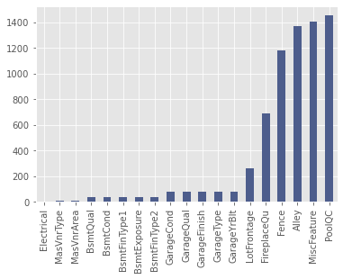

```python
nullvals = data.isnull().sum()
nullvals = nullvals[nullvals > 0]
nullvals.sort_values(inplace=True)
nullvals.plot.bar(color='#4d5d8c')
```

```python
missing_qual = [missing for missing in nullvals.index if missing in qualitative]
data[missing_qual].nunique()
```

```
Electrical      5
MasVnrType      4
BsmtQual        4
BsmtCond        4
BsmtFinType1    6
BsmtExposure    4
BsmtFinType2    6
GarageCond      5
GarageQual      5
GarageFinish    3
GarageType      6
FireplaceQu     5
Fence           4
Alley           2
MiscFeature     4
PoolQC          3
dtype: int64
```

```python
missing_quant = [missing for missing in nullvals.index if missing in quantitative]
data[missing_quant]
```

|  | MasVnrArea | GarageYrBlt | LotFrontage |
| --- | --- | --- | --- |
| 0 | 196.0 | 2003.0 | 65.0 |
| 1 | 0.0 | 1976.0 | 80.0 |
| 2 | 162.0 | 2001.0 | 68.0 |
| 3 | 0.0 | 1998.0 | 60.0 |
| 4 | 350.0 | 2000.0 | 84.0 |
| ... | ... | ... | ... |
| 1455 | 0.0 | 1999.0 | 62.0 |
| 1456 | 119.0 | 1978.0 | 85.0 |
| 1457 | 0.0 | 1941.0 | 66.0 |
| 1458 | 0.0 | 1950.0 | 68.0 |
| 1459 | 0.0 | 1965.0 | 75.0 |

1460 rows × 3 columns

```python
data[missing_quant].describe()
```

|  | MasVnrArea | GarageYrBlt | LotFrontage |
| --- | --- | --- | --- |
| count | 1452.000000 | 1379.000000 | 1201.000000 |
| mean | 103.685262 | 1978.506164 | 70.049958 |
| std | 181.066207 | 24.689725 | 24.284752 |
| min | 0.000000 | 1900.000000 | 21.000000 |
| 25% | 0.000000 | 1961.000000 | 59.000000 |
| 50% | 0.000000 | 1980.000000 | 69.000000 |
| 75% | 166.000000 | 2002.000000 | 80.000000 |
| max | 1600.000000 | 2010.000000 | 313.000000 |

According to the data description, the null values for the qualitative data correspond to not having that feature in the house, so filling that with a new categorical value, DNE, should be a good treatment.

```python
data[missing_quant] = data[missing_quant].fillna(value=0)
```

```python
data[missing_quant].isnull().any()
```

```
MasVnrArea     False
GarageYrBlt    False
LotFrontage    False
dtype: bool
```

```python
data[missing_qual] = data[missing_qual].fillna(value='DNE')
data[missing_qual].head()
```

|  | Electrical | MasVnrType | BsmtQual | BsmtCond | BsmtFinType1 | BsmtExposure | BsmtFinType2 | GarageCond | GarageQual | GarageFinish | GarageType | FireplaceQu | Fence | Alley | MiscFeature | PoolQC |
| --- | --- | --- | --- | --- | --- | --- | --- | --- | --- | --- | --- | --- | --- | --- | --- | --- |
| 0 | SBrkr | BrkFace | Gd | TA | GLQ | No | Unf | TA | TA | RFn | Attchd | DNE | DNE | DNE | DNE | DNE |
| 1 | SBrkr | None | Gd | TA | ALQ | Gd | Unf | TA | TA | RFn | Attchd | TA | DNE | DNE | DNE | DNE |
| 2 | SBrkr | BrkFace | Gd | TA | GLQ | Mn | Unf | TA | TA | RFn | Attchd | TA | DNE | DNE | DNE | DNE |
| 3 | SBrkr | None | TA | Gd | ALQ | No | Unf | TA | TA | Unf | Detchd | Gd | DNE | DNE | DNE | DNE |
| 4 | SBrkr | BrkFace | Gd | TA | GLQ | Av | Unf | TA | TA | RFn | Attchd | TA | DNE | DNE | DNE | DNE |

```python
data.isnull().any().sum()
```

```
0
```

# Visualizing Dataset

## SalePrice

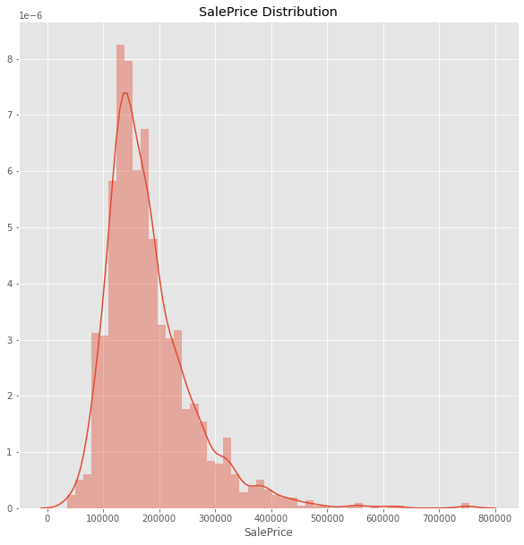

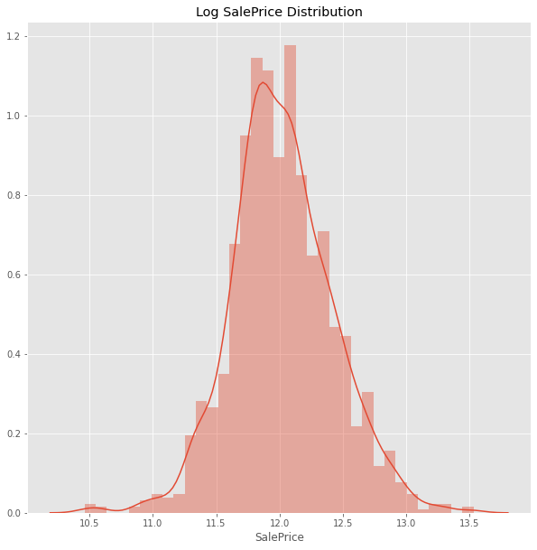

```python
y = data['SalePrice']

plt.figure(figsize=(10,10))
plt.title('SalePrice Distribution')
sns.distplot(y)

y = np.log(data['SalePrice'])

plt.figure(figsize=(10,10))
plt.title('Log SalePrice Distribution')
sns.distplot(y)
```

SalePrice has some outliers which could be pulled in with a log transformation if we were to do regression, but for a decision tree the outliers shouldn't be an issue.

## Quantitative Data

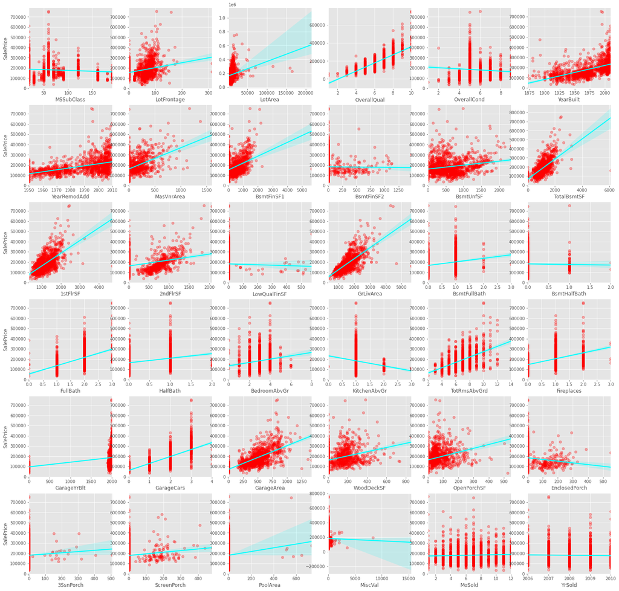

```python
plt.figure(figsize=(25, 25))

for n in range(0, len(quantitative)):
    rows = math.ceil(len(quantitative)/6)
    plt.subplot(rows, 6, n+1)
    sns.regplot(x=data[quantitative[n]], y=data.SalePrice, line_kws={'color':'cyan'}, scatter_kws={'color':'red', 'alpha': 0.3})
    if n%6 > 0:
        plt.ylabel('')

plt.show()
```

**MSSubClass** is the type of dwelling, and it is identified by numbers. This feature could be re ordered, made into a categorical feature, or removed(as the type of dwelling is also reflected in the other features).

**KitchenAbvGr** also has a strange behavior since the majority have 1, so it's highly influenced by the tail of the distribution. **OverallCond** suffers from a similar problem, and the regression line is the opposite of what we expect.

**GarageYrBlt** seems to suffer from the 0s we filled in for null values. This feature could potentially be represented in GarageCars or GarageArea, and removed entirely or fill in the null values with something else. Two possibilities are the mean of the other values, or the **YearBuilt**

```python
for n in range(0, len(data.GarageYrBlt)):
    if data.GarageYrBlt[n] == 0:
        data.loc[n, 'GarageYrBlt'] = data.YearBuilt[n]
```

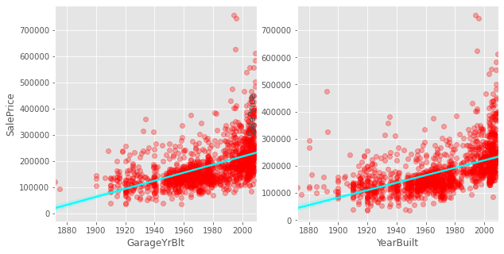

```python
plt.figure(figsize=(10,5))

plt.subplot(1, 2, 1)
sns.regplot(x=data.GarageYrBlt, y=data.SalePrice, line_kws={'color':'cyan'}, scatter_kws={'color':'red', 'alpha': 0.3})

plt.subplot(1, 2, 2)
sns.regplot(x=data.YearBuilt, y=data.SalePrice, line_kws={'color':'cyan'}, scatter_kws={'color':'red', 'alpha': 0.3})
plt.show()
```

```python
mean_squared_error(data.YearBuilt, data.GarageYrBlt)**(1/2)
```

```
16.986457135830214
```

After setting the zero values in **GarageYrBlt** to the values of **YearBuilt**, the graph for **GarageYrBlt** appears to be a more well behaved feature. It is very similar to **YearBuilt** and may or may not improve the model by dropping **GarageYrBlt**.

```python
for n in range(0, len(data.MSSubClass)):
    data.loc[n, 'MSSubClass'] = str(data.MSSubClass[n])
qualitative.append('MSSubClass')
quantitative.remove('MSSubClass')
```

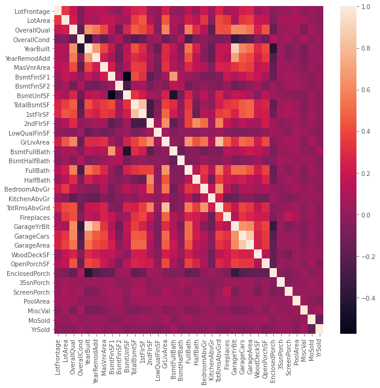

```python
plt.figure(figsize=(10,10))
corr = data[quantitative].corr('spearman')
sns.heatmap(corr)
```

```python
corr['YearBuilt']['GarageYrBlt']
```

```
0.8952246204868528
```

# Categorical Data

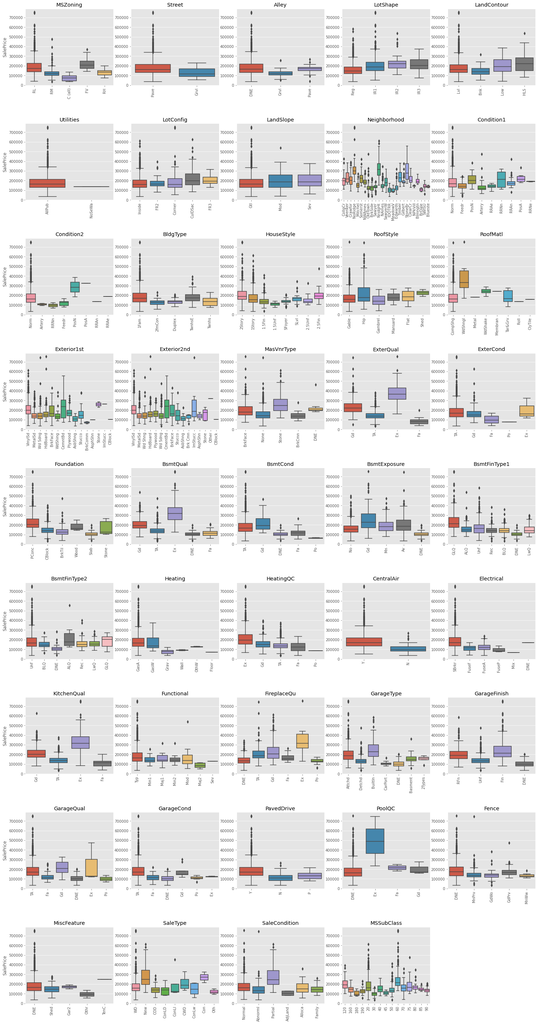

```python
plt.figure(figsize=(25,50))

for n in range(0, len(qualitative)):
    rows = math.ceil(len(qualitative)/5)
    plt.subplot(rows, 5, n+1)
    sns.boxplot(x=data[qualitative[n]], y=data.SalePrice)
    x=plt.xticks(rotation=90)
    plt.xlabel('')
    plt.title(f'{qualitative[n]}')
    if n%5 > 0:
        plt.ylabel('')


plt.subplots_adjust(hspace=0.5)
plt.show()
```

If regression were to be used, creating dummy variables or OneHotEncoding should be used. For a decision tree this doesn't need to be done.

```python
one_hot = pd.get_dummies(data[qualitative], drop_first=True)
one_hot
```

|  | MSZoning_FV | MSZoning_RH | MSZoning_RL | MSZoning_RM | Street_Pave | Alley_Grvl | Alley_Pave | LotShape_IR2 | LotShape_IR3 | LotShape_Reg | ... | MSSubClass_30 | MSSubClass_40 | MSSubClass_45 | MSSubClass_50 | MSSubClass_60 | MSSubClass_70 | MSSubClass_75 | MSSubClass_80 | MSSubClass_85 | MSSubClass_90 |
| --- | --- | --- | --- | --- | --- | --- | --- | --- | --- | --- | --- | --- | --- | --- | --- | --- | --- | --- | --- | --- | --- |
| 0 | 0 | 0 | 1 | 0 | 1 | 0 | 0 | 0 | 0 | 1 | ... | 0 | 0 | 0 | 0 | 1 | 0 | 0 | 0 | 0 | 0 |
| 1 | 0 | 0 | 1 | 0 | 1 | 0 | 0 | 0 | 0 | 1 | ... | 0 | 0 | 0 | 0 | 0 | 0 | 0 | 0 | 0 | 0 |
| 2 | 0 | 0 | 1 | 0 | 1 | 0 | 0 | 0 | 0 | 0 | ... | 0 | 0 | 0 | 0 | 1 | 0 | 0 | 0 | 0 | 0 |
| 3 | 0 | 0 | 1 | 0 | 1 | 0 | 0 | 0 | 0 | 0 | ... | 0 | 0 | 0 | 0 | 0 | 1 | 0 | 0 | 0 | 0 |
| 4 | 0 | 0 | 1 | 0 | 1 | 0 | 0 | 0 | 0 | 0 | ... | 0 | 0 | 0 | 0 | 1 | 0 | 0 | 0 | 0 | 0 |
| ... | ... | ... | ... | ... | ... | ... | ... | ... | ... | ... | ... | ... | ... | ... | ... | ... | ... | ... | ... | ... | ... |
| 1455 | 0 | 0 | 1 | 0 | 1 | 0 | 0 | 0 | 0 | 1 | ... | 0 | 0 | 0 | 0 | 1 | 0 | 0 | 0 | 0 | 0 |
| 1456 | 0 | 0 | 1 | 0 | 1 | 0 | 0 | 0 | 0 | 1 | ... | 0 | 0 | 0 | 0 | 0 | 0 | 0 | 0 | 0 | 0 |
| 1457 | 0 | 0 | 1 | 0 | 1 | 0 | 0 | 0 | 0 | 1 | ... | 0 | 0 | 0 | 0 | 0 | 1 | 0 | 0 | 0 | 0 |
| 1458 | 0 | 0 | 1 | 0 | 1 | 0 | 0 | 0 | 0 | 1 | ... | 0 | 0 | 0 | 0 | 0 | 0 | 0 | 0 | 0 | 0 |
| 1459 | 0 | 0 | 1 | 0 | 1 | 0 | 0 | 0 | 0 | 1 | ... | 0 | 0 | 0 | 0 | 0 | 0 | 0 | 0 | 0 | 0 |

1460 rows × 239 columns

```python
one_hot_encoded = data[quantitative]
one_hot_encoded[one_hot.columns] = one_hot
one_hot_encoded
```

|  | LotFrontage | LotArea | OverallQual | OverallCond | YearBuilt | YearRemodAdd | MasVnrArea | BsmtFinSF1 | BsmtFinSF2 | BsmtUnfSF | ... | MSSubClass_30 | MSSubClass_40 | MSSubClass_45 | MSSubClass_50 | MSSubClass_60 | MSSubClass_70 | MSSubClass_75 | MSSubClass_80 | MSSubClass_85 | MSSubClass_90 |
| --- | --- | --- | --- | --- | --- | --- | --- | --- | --- | --- | --- | --- | --- | --- | --- | --- | --- | --- | --- | --- | --- |
| 0 | 65.0 | 8450 | 7 | 5 | 2003 | 2003 | 196.0 | 706 | 0 | 150 | ... | 0 | 0 | 0 | 0 | 1 | 0 | 0 | 0 | 0 | 0 |
| 1 | 80.0 | 9600 | 6 | 8 | 1976 | 1976 | 0.0 | 978 | 0 | 284 | ... | 0 | 0 | 0 | 0 | 0 | 0 | 0 | 0 | 0 | 0 |
| 2 | 68.0 | 11250 | 7 | 5 | 2001 | 2002 | 162.0 | 486 | 0 | 434 | ... | 0 | 0 | 0 | 0 | 1 | 0 | 0 | 0 | 0 | 0 |
| 3 | 60.0 | 9550 | 7 | 5 | 1915 | 1970 | 0.0 | 216 | 0 | 540 | ... | 0 | 0 | 0 | 0 | 0 | 1 | 0 | 0 | 0 | 0 |
| 4 | 84.0 | 14260 | 8 | 5 | 2000 | 2000 | 350.0 | 655 | 0 | 490 | ... | 0 | 0 | 0 | 0 | 1 | 0 | 0 | 0 | 0 | 0 |
| ... | ... | ... | ... | ... | ... | ... | ... | ... | ... | ... | ... | ... | ... | ... | ... | ... | ... | ... | ... | ... | ... |
| 1455 | 62.0 | 7917 | 6 | 5 | 1999 | 2000 | 0.0 | 0 | 0 | 953 | ... | 0 | 0 | 0 | 0 | 1 | 0 | 0 | 0 | 0 | 0 |
| 1456 | 85.0 | 13175 | 6 | 6 | 1978 | 1988 | 119.0 | 790 | 163 | 589 | ... | 0 | 0 | 0 | 0 | 0 | 0 | 0 | 0 | 0 | 0 |
| 1457 | 66.0 | 9042 | 7 | 9 | 1941 | 2006 | 0.0 | 275 | 0 | 877 | ... | 0 | 0 | 0 | 0 | 0 | 1 | 0 | 0 | 0 | 0 |
| 1458 | 68.0 | 9717 | 5 | 6 | 1950 | 1996 | 0.0 | 49 | 1029 | 0 | ... | 0 | 0 | 0 | 0 | 0 | 0 | 0 | 0 | 0 | 0 |
| 1459 | 75.0 | 9937 | 5 | 6 | 1965 | 1965 | 0.0 | 830 | 290 | 136 | ... | 0 | 0 | 0 | 0 | 0 | 0 | 0 | 0 | 0 | 0 |

1460 rows × 274 columns

# Training the model

```python
X = one_hot_encoded
y = np.log(data['SalePrice'])
X_train, X_test, y_train, y_test = train_test_split(X, y, test_size=0.2, random_state=0)
```

```python
my_model = XGBRegressor(n_estimators=1000, learning_rate=0.01)
my_model.fit(X_train, y_train, verbose=False)
```

```
XGBRegressor(base_score=0.5, booster='gbtree', colsample_bylevel=1,
             colsample_bynode=1, colsample_bytree=1, gamma=0, gpu_id=-1,
             importance_type='gain', interaction_constraints='',
             learning_rate=0.01, max_delta_step=0, max_depth=6,
             min_child_weight=1, missing=nan, monotone_constraints='()',
             n_estimators=1000, n_jobs=0, num_parallel_tree=1, random_state=0,
             reg_alpha=0, reg_lambda=1, scale_pos_weight=1, subsample=1,
             tree_method='exact', validate_parameters=1, verbosity=None)
```

```python
predictions = my_model.predict(X_test)
```

```python
print("Root Mean Squared Error: " + str(mean_squared_error(predictions, y_test)**1/2))
```

```
Root Mean Squared Error: 0.007848786739381095
```

```python
print("Mean absolute Error: " + str(mean_absolute_error(np.e**predictions, np.e**y_test)))
```

[output not shown]

```python
r2_score(predictions, y_test)
```

```
0.8915181757053858
```

```python
resid = predictions - y_test
```

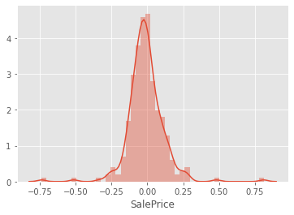

```python
sns.distplot(resid)
plt.show()
```